# Econgeo ejemplos MD

Instalar librerías

install.packages(“devtools”) #or install.packages(“devtools”, type = “win.binary”)

library(devtools)

devtools::install_github(“PABalland/EconGeo”, force = T)

Llamar librerías

```r
library (EconGeo)
```

```
##  Balland, P.A. (2017) Economic Geography in R: Introduction to the EconGeo Package, Papers in Evolutionary Economic Geography, 17 (09): 1-75
```

1. Graficar una curva de Hoover

Generar vectores sobre estadística industrial y poblacional

```r
ind <- c(0, 10, 10, 30, 50)
pop <- c(10, 15, 20, 25, 30)
```

Ver el vector ind

```r
ind
```

```
## [1]  0 10 10 30 50
```

Ver el vector pop

```r
pop
```

```
## [1] 10 15 20 25 30
```

Correr la funcion (30% de la población produce 50% de los resultados industriales)

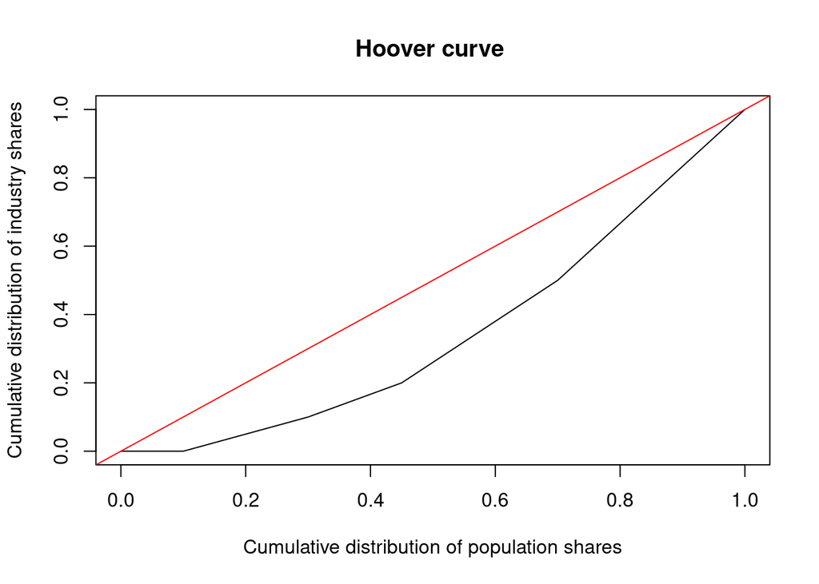

```r
Hoover.curve (ind, pop)
```

Calcular el Gini correspondiene al índice Hoover

```r
Hoover.Gini (ind, pop)
```

```
## [1] 0.31
```

2. GINI

Generar vectores de conteo industrial

```r
ind <- c(0, 10, 10, 30, 50)
```

Crrer la función

```r
Gini (ind)
```

```
## [1] 0.48
```

Generar una matriz región - industria

```r
mat1 = matrix (
  c (0, 1, 0, 0,
     0, 1, 0, 0,
     0, 1, 0, 0,
     0, 1, 0, 1,
     0, 1, 1, 1), ncol = 4, byrow = T)
rownames(mat1) <- c ("R1", "R2", "R3", "R4", "R5")
colnames(mat1) <- c ("I1", "I2", "I3", "I4")
```

Correr la función

```r
Gini (mat1)
```

```
##   Industry Gini
## 1       I1  NaN
## 2       I2  0.0
## 3       I3  0.8
## 4       I4  0.6
```

Correr la función solo para la industria 1 (igualdad perfecta)

```r
Gini (mat1[,1])
```

```
## [1] NaN
```

Correr la función solo para la industria 2 (igualdad perfecta)

```r
Gini (mat1[,2])
```

```
## [1] 0
```

Correr la función solo para la industria 3 (desigualdad perfecta: max Gini = (5-1)/5)

```r
Gini (mat1[,3])
```

```
## [1] 0.8
```

Correr la función solo para la industria 4 (top 40% produce el 100% de los resultados)

```r
Gini (mat1[,4])
```

```
## [1] 0.6
```

3. HOOVER. GINI

Generar vectores de estadística industrial y poblacional

```r
ind <- c(0, 10, 10, 30, 50)
pop <- c(10, 15, 20, 25, 30)
```

Correr la funcion (30% de la población produce el 50% de los resultados industriales)

```r
Hoover.Gini (ind, pop)
```

```
## [1] 0.31
```

Generar una matriz región - industria

```r
mat2 = matrix (
  c (0, 10, 0, 0,
     0, 15, 0, 0,
     0, 20, 0, 0,
     0, 25, 0, 1,
     0, 30, 1, 1), ncol = 4, byrow = T)
rownames(mat2) <- c ("R1", "R2", "R3", "R4", "R5")
colnames(mat2) <- c ("I1", "I2", "I3", "I4")
```

Correr la función

```r
Hoover.Gini (mat2, pop)
```

```
##   Industry Hoover.Gini
## 1       I1         NaN
## 2       I2       0.000
## 3       I3       0.700
## 4       I4       0.475
```

Correr la función agregando todas las industrias

```r
Hoover.Gini (rowSums(mat2), pop)
```

```
## [1] 0.015
```

Correr la función solo para la industria 1

```r
Hoover.Gini (mat2[,1], pop)
```

```
## [1] NaN
```

Correr la función solo para la industria 2 (perfectamente proporcional a la poblaciÃ³n)

```r
Hoover.Gini (mat2[,2], pop)
```

```
## [1] 0
```

Correr la función solo para la industria 3 (30% de la población produce el 100% de la producción)

```r
Hoover.Gini (mat2[,3], pop)
```

```
## [1] 0.7
```

Correr la función solo para la industria 4 (55% del población produce el 100% de la producción)

```r
Hoover.Gini (mat2[,4], pop)
```

```
## [1] 0.475
```

4. LOCATIONAL.GINI

Generar una matriz región - industria

```r
mat3 = matrix (
  c (100, 0, 0, 0, 0,
     0, 15, 5, 70, 10,
     0, 20, 10, 20, 50,
     0, 25, 30, 5, 40,
     0, 40, 55, 5, 0), ncol = 5, byrow = T)
rownames(mat3) <- c ("R1", "R2", "R3", "R4", "R5")
colnames(mat3) <- c ("I1", "I2", "I3", "I4", "I5")
```

Correr la función

```r
locational.Gini (mat3)
```

```
##   Industry Loc.Gini
## 1       I1     0.40
## 2       I2     0.18
## 3       I3     0.27
## 4       I4     0.31
## 5       I5     0.28
```

5. LOCATIONAL.GINI.CURVE

Generar una matriz región - industria

```r
mat3 = matrix (
  c (100, 0, 0, 0, 0,
     0, 15, 5, 70, 10,
     0, 20, 10, 20, 50,
     0, 25, 30, 5, 40,
     0, 40, 55, 5, 0), ncol = 5, byrow = T)
rownames(mat3) <- c ("R1", "R2", "R3", "R4", "R5")
colnames(mat3) <- c ("I1", "I2", "I3", "I4", "I5")
```

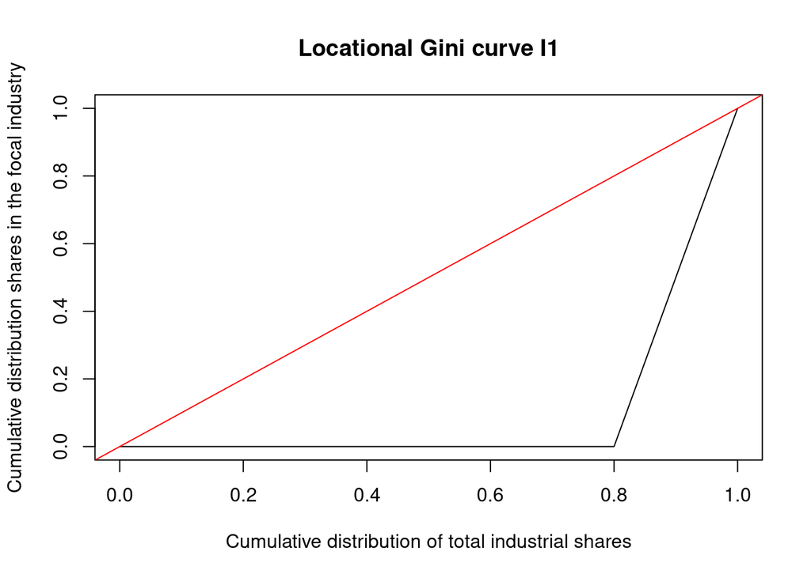

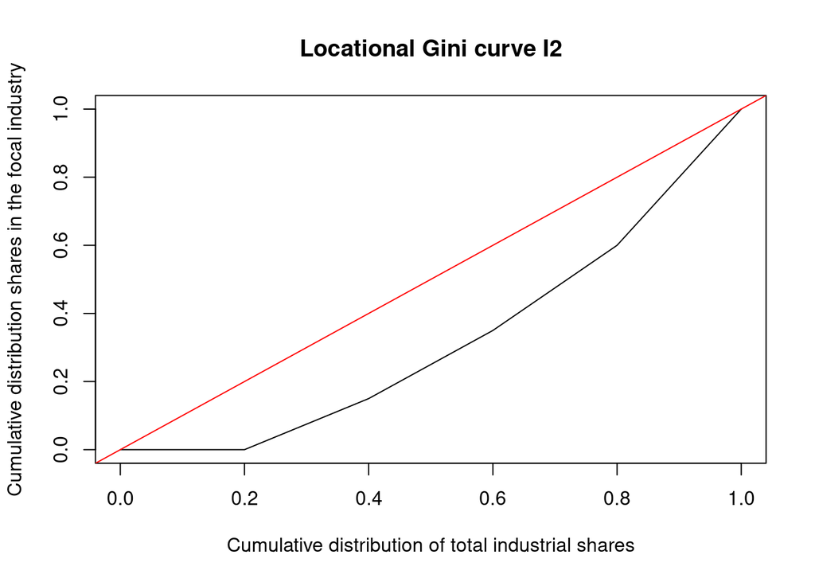

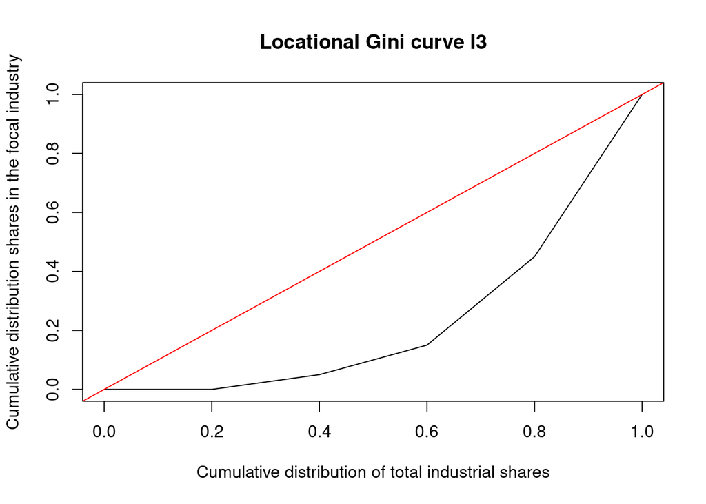

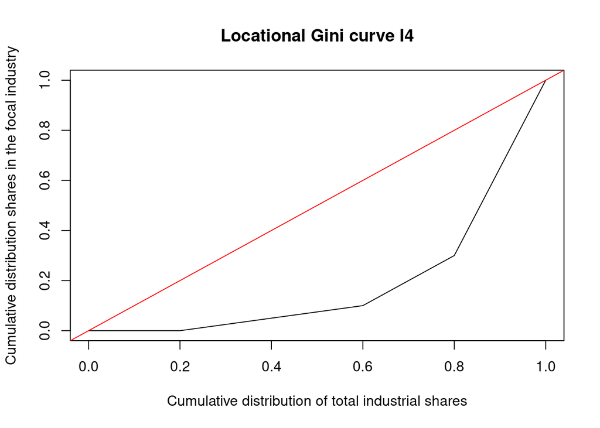

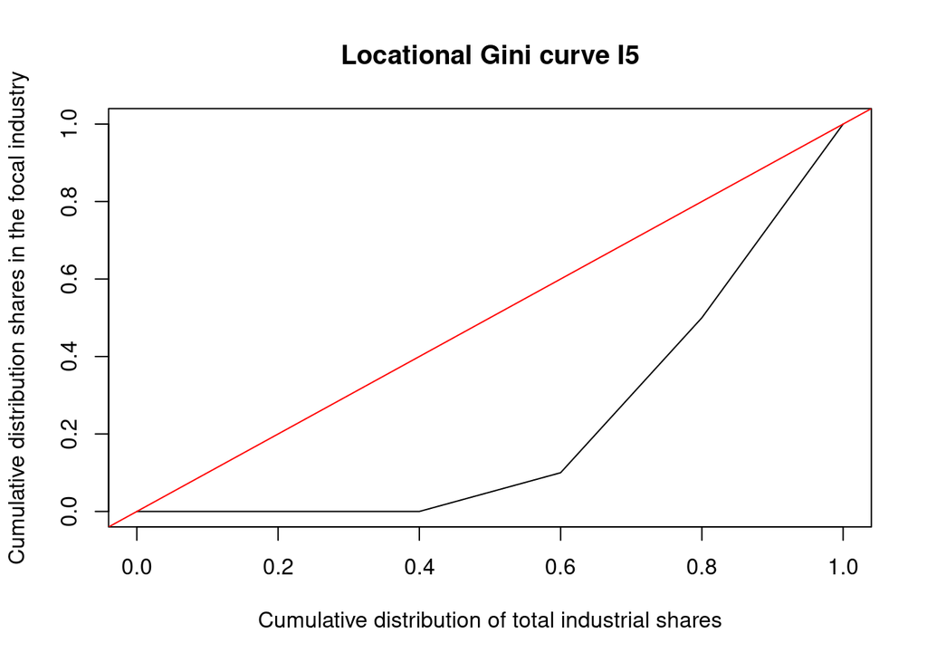

```r
locational.Gini.curve (mat3)
```

```r
locational.Gini.curve (mat3, pdf = TRUE)
```

```
## [1] "locational.Gini.curve.pdf has been saved to your current working directory"
```

6. LORENZ.CURVE

Generar vectores de estadística industrial

```r
ind <- c(0, 10, 10, 30, 50)
```

Correr la función

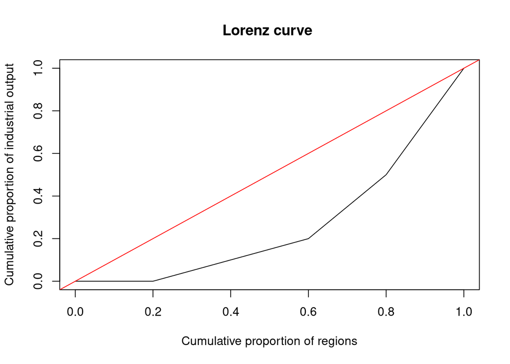

```r
Lorenz.curve (ind)
```

```r
Lorenz.curve (ind, pdf = TRUE)
```

```
## [1] "Lorenz.curve.pdf has been saved to your current working directory"
```

```r
Lorenz.curve (ind, plot = FALSE)
```

```
## $cum.reg
## [1] 0.0 0.2 0.4 0.6 0.8 1.0
##
## $cum.out
## [1] 0.0 0.0 0.1 0.2 0.5 1.0
```

Generar una matriz región - industria

```r
mat1 = matrix (
  c (0, 1, 0, 0,
     0, 1, 0, 0,
     0, 1, 0, 0,
     0, 1, 0, 1,
     0, 1, 1, 1), ncol = 4, byrow = T)
rownames(mat1) <- c ("R1", "R2", "R3", "R4", "R5")
colnames(mat1) <- c ("I1", "I2", "I3", "I4")
```

Correr la función

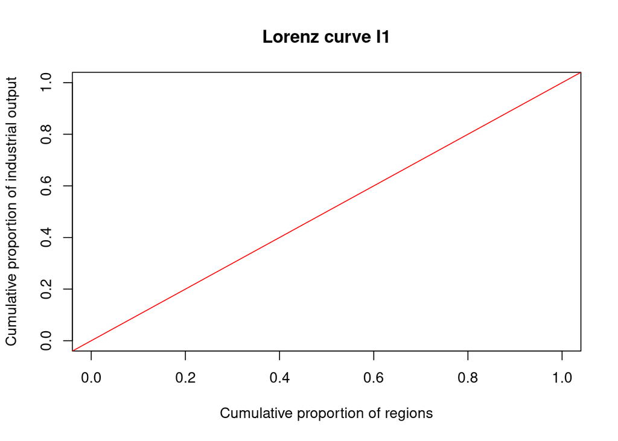

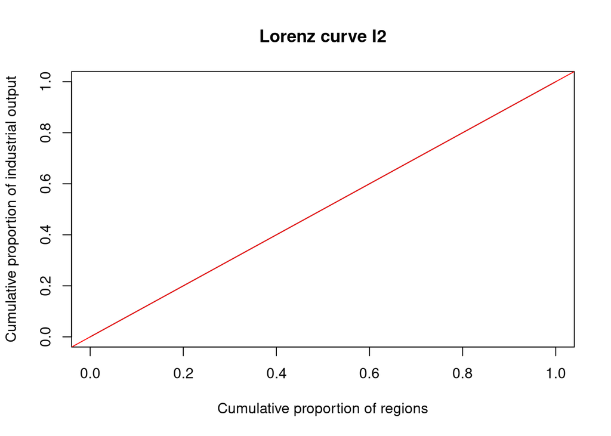

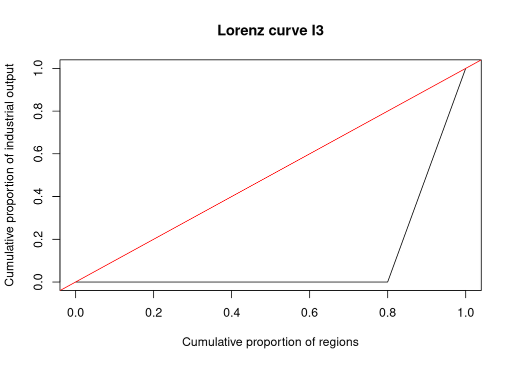

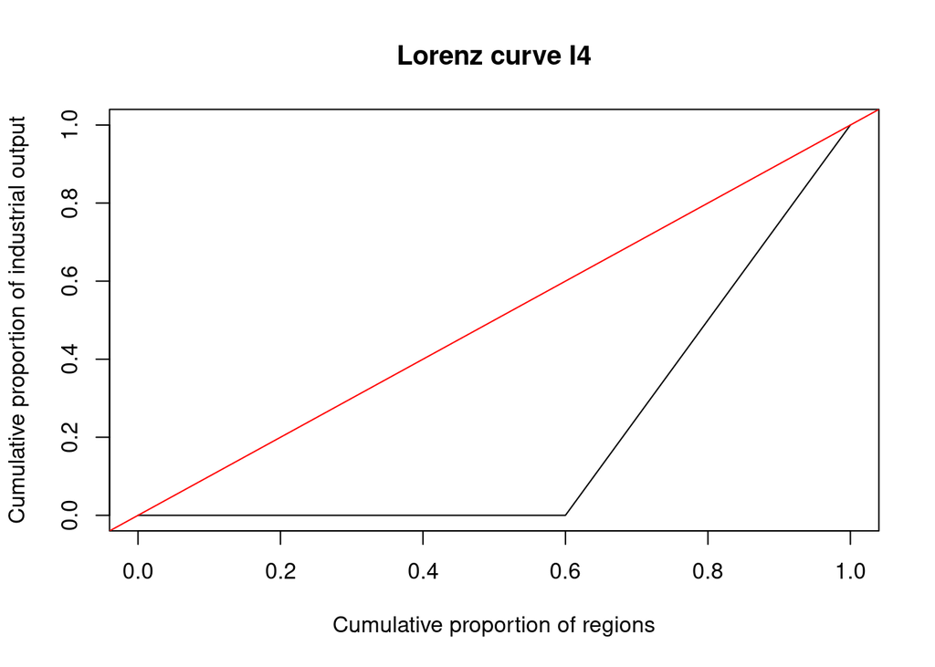

```r
Lorenz.curve (mat1)
```

```r
Lorenz.curve (mat1, pdf = TRUE)
```

```
## [1] "Lorenz.curve.pdf has been saved to your current working directory"
```

```r
Lorenz.curve (mat1, plot = FALSE)
```

```
## $cum.reg
## [1] 0.0 0.2 0.4 0.6 0.8 1.0
##
## $cum.out
##      R1  R2  R3  R4  R5
##   0 NaN NaN NaN NaN NaN
```

Correr la función agregando todas las industrias

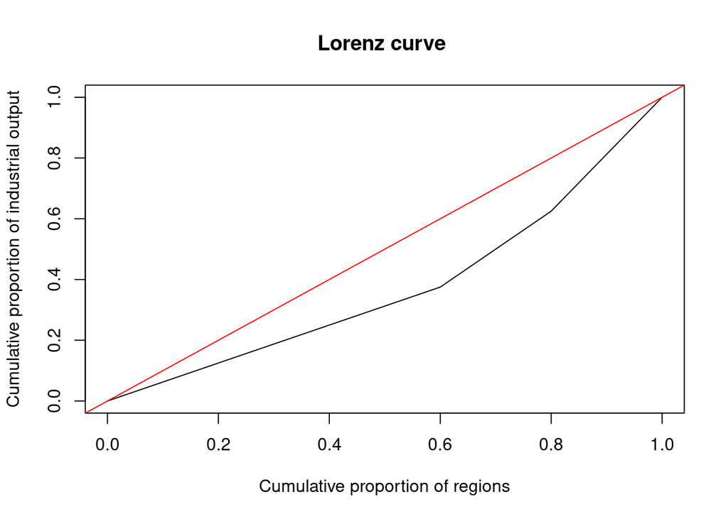

```r
Lorenz.curve (rowSums(mat1))
```

```r
Lorenz.curve (rowSums(mat1), pdf = TRUE)
```

```
## [1] "Lorenz.curve.pdf has been saved to your current working directory"
```

```r
Lorenz.curve (rowSums(mat1), plot = FALSE)
```

```
## $cum.reg
## [1] 0.0 0.2 0.4 0.6 0.8 1.0
##
## $cum.out
##          R1    R2    R3    R4    R5
## 0.000 0.125 0.250 0.375 0.625 1.000
```

Correr la función solo para la industria 1 (igualdad perfecta)

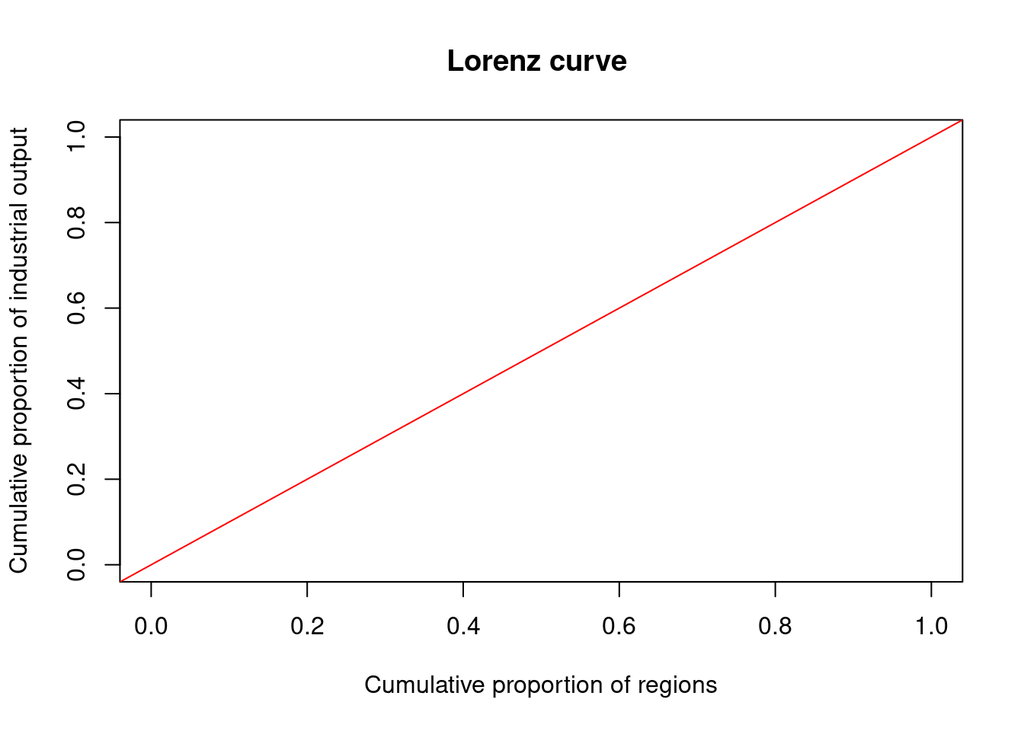

```r
Lorenz.curve (mat1[,1])
```

```r
Lorenz.curve (mat1[,1], pdf = TRUE)
```

```
## [1] "Lorenz.curve.pdf has been saved to your current working directory"
```

```r
Lorenz.curve (mat1[,1], plot = FALSE)
```

```
## $cum.reg
## [1] 0.0 0.2 0.4 0.6 0.8 1.0
##
## $cum.out
##      R1  R2  R3  R4  R5
##   0 NaN NaN NaN NaN NaN
```

Correr la función solo para la industria 2 (igualdad perfecta)

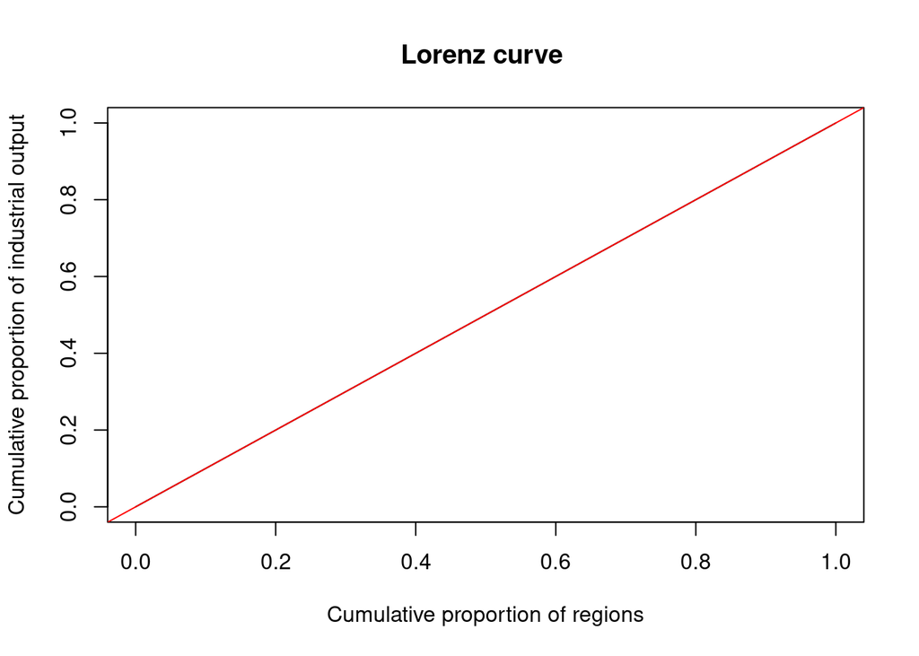

```r
Lorenz.curve (mat1[,2])
```

```r
Lorenz.curve (mat1[,2], pdf = TRUE)
```

```
## [1] "Lorenz.curve.pdf has been saved to your current working directory"
```

```r
Lorenz.curve (mat1[,2], plot = FALSE)
```

```
## $cum.reg
## [1] 0.0 0.2 0.4 0.6 0.8 1.0
##
## $cum.out
##      R1  R2  R3  R4  R5
## 0.0 0.2 0.4 0.6 0.8 1.0
```

Correr la función solo para la industria 3 (desigualdad perfecta)

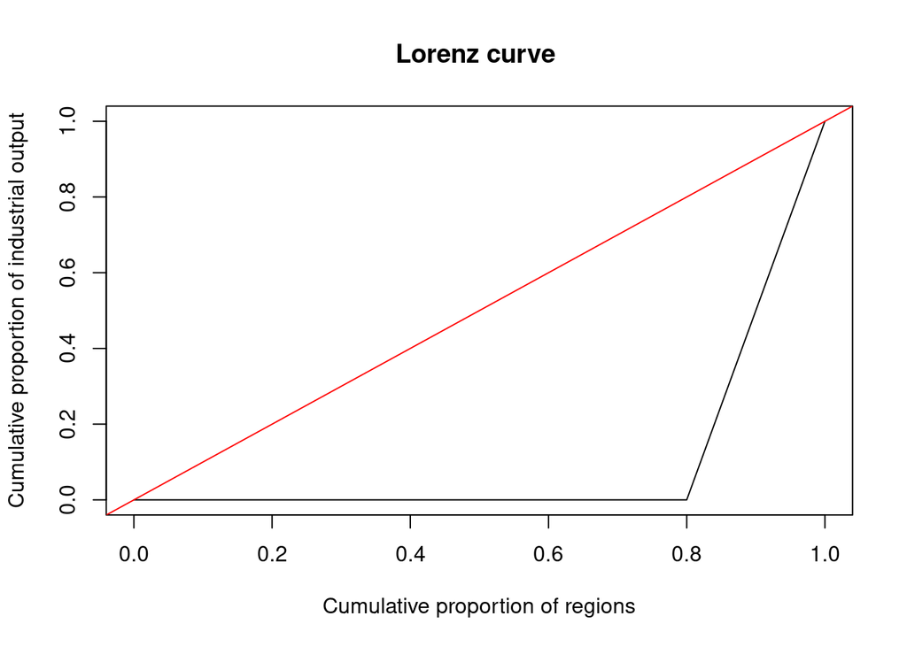

```r
Lorenz.curve (mat1[,3])
```

```r
Lorenz.curve (mat1[,3], pdf = TRUE)
```

```
## [1] "Lorenz.curve.pdf has been saved to your current working directory"
```

```r
Lorenz.curve (mat1[,3], plot = FALSE)
```

```
## $cum.reg
## [1] 0.0 0.2 0.4 0.6 0.8 1.0
##
## $cum.out
##    R1 R2 R3 R4 R5
##  0  0  0  0  0  1
```

Correr la función solo para la industria 4 (el top 40% produce el 100% de los resultados)

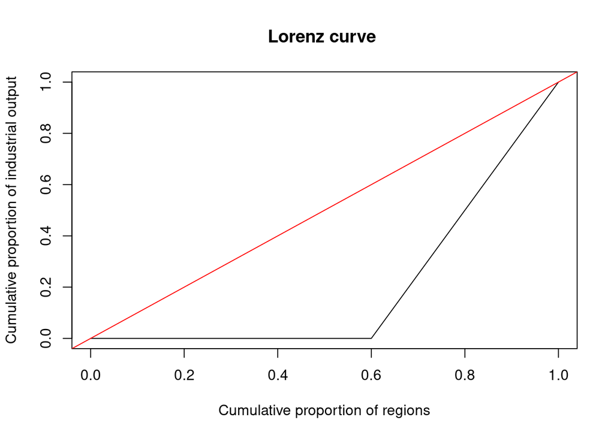

```r
Lorenz.curve (mat1[,4])
```

```r
Lorenz.curve (mat1[,4], pdf = TRUE)
```

```
## [1] "Lorenz.curve.pdf has been saved to your current working directory"
```

```r
Lorenz.curve (mat1[,4], plot = FALSE)
```

```
## $cum.reg
## [1] 0.0 0.2 0.4 0.6 0.8 1.0
##
## $cum.out
##      R1  R2  R3  R4  R5
## 0.0 0.0 0.0 0.0 0.5 1.0
```

Comparar la distribución de las industrias

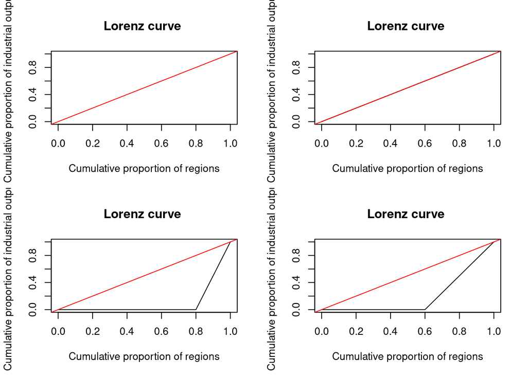

```r
par(mfrow=c(2,2))
Lorenz.curve (mat1[,1])
Lorenz.curve (mat1[,2])
Lorenz.curve (mat1[,3])
Lorenz.curve (mat1[,4])
```